# skimage.data

Example images and datasets.

A curated set of general purpose and scientific images used in tests, examples, and documentation.

Newer datasets are no longer included as part of the package, but are downloaded on demand. To make data available offline, use `download_all()`.

| `astronaut` | Color image of the astronaut Eileen Collins. |
| --- | --- |
| `binary_blobs` | Generate synthetic binary image with several rounded blob-like objects. |
| `brain` | Subset of data from the University of North Carolina Volume Rendering Test Data Set. |
| `brick` | Brick wall. |
| `camera` | Gray-level "camera" image. |
| `cat` | Chelsea the cat. |
| `cell` | Cell floating in saline. |
| `cells3d` | 3D fluorescence microscopy image of cells. |
| `checkerboard` | Checkerboard image. |
| `chelsea` | Chelsea the cat. |
| `clock` | Motion blurred clock. |
| `coffee` | Coffee cup. |
| `coins` | Greek coins from Pompeii. |
| `colorwheel` | Color Wheel. |
| `download_all` | Download all datasets for use with scikit-image offline. |
| `eagle` | A golden eagle. |
| `file_hash` | Calculate the hash of a given file. |
| `grass` | Grass. |
| `gravel` | Gravel |
| `horse` | Black and white silhouette of a horse. |
| `hubble_deep_field` | Hubble eXtreme Deep Field. |
| `human_mitosis` | Image of human cells undergoing mitosis. |
| `immunohistochemistry` | Immunohistochemical (IHC) staining with hematoxylin counterstaining. |
| `kidney` | Mouse kidney tissue. |
| `lbp_frontal_face_cascade_filename` | Return the path to the XML file containing the weak classifier cascade. |
| `lfw_subset` | Subset of data from the LFW dataset. |
| `lily` | Lily of the valley plant stem. |
| `logo` | Scikit-image logo, a RGBA image. |
| `microaneurysms` | Gray-level "microaneurysms" image. |
| `moon` | Surface of the moon. |
| `nickel_solidification` | Image sequence of synchrotron x-radiographs showing the rapid solidification of a nickel alloy sample. |
| `page` | Scanned page. |
| `palisades_of_vogt` | Return image sequence of in-vivo tissue showing the palisades of Vogt. |
| `protein_transport` | Microscopy image sequence with fluorescence tagging of proteins re-localizing from the cytoplasmic area to the nuclear envelope. |
| `retina` | Human retina. |
| `rocket` | Launch photo of DSCOVR on Falcon 9 by SpaceX. |
| `shepp_logan_phantom` | Shepp Logan Phantom. |
| `skin` | Microscopy image of dermis and epidermis (skin layers). |
| `stereo_motorcycle` | Rectified stereo image pair with ground-truth disparities. |
| `text` | Gray-level "text" image used for corner detection. |
| `vortex` | Case B1 image pair from the first PIV challenge. |

**`skimage.data.astronaut()` [[source]](https://github.com/scikit-image/scikit-image/blob/v0.26.0/skimage/data/_fetchers.py#L403-L422)**

Color image of the astronaut Eileen Collins.

Photograph of Eileen Collins, an American astronaut. She was selected as an astronaut in 1992 and first piloted the space shuttle STS-63 in 1995. She retired in 2006 after spending a total of 38 days, 8 hours and 10 minutes in outer space.

No known copyright restrictions, released into the public domain.

**Returns:**

**`astronaut(512, 512, 3) uint8 ndarray`**

Astronaut image.

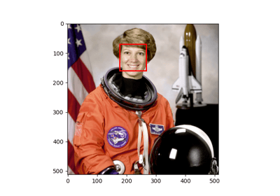

[Face detection using a cascade classifier](https://scikit-image.org/docs/0.26.x/auto_examples/applications/plot_face_detection.html)

Face detection using a cascade classifier

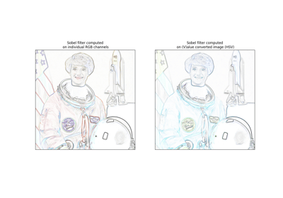

[Adapting gray-scale filters to RGB images](https://scikit-image.org/docs/0.26.x/auto_examples/color_exposure/plot_adapt_rgb.html)

Adapting gray-scale filters to RGB images

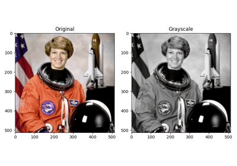

[RGB to grayscale](https://scikit-image.org/docs/0.26.x/auto_examples/color_exposure/plot_rgb_to_gray.html)

RGB to grayscale

[General-purpose images](https://scikit-image.org/docs/0.26.x/auto_examples/data/plot_general.html)

General-purpose images

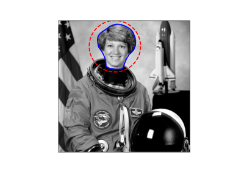

[Active Contour Model](https://scikit-image.org/docs/0.26.x/auto_examples/edges/plot_active_contours.html)

Active Contour Model

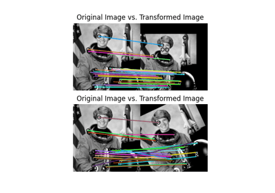

[BRIEF binary descriptor](https://scikit-image.org/docs/0.26.x/auto_examples/features_detection/plot_brief.html)

BRIEF binary descriptor

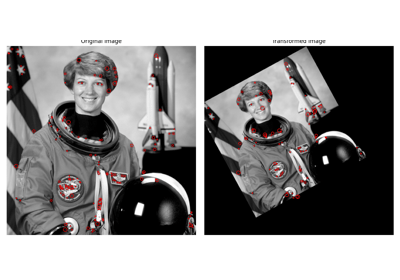

[CENSURE feature detector](https://scikit-image.org/docs/0.26.x/auto_examples/features_detection/plot_censure.html)

CENSURE feature detector

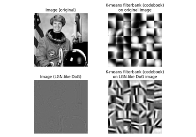

[Gabors / Primary Visual Cortex “Simple Cells” from an Image](https://scikit-image.org/docs/0.26.x/auto_examples/features_detection/plot_gabors_from_astronaut.html)

Gabors / Primary Visual Cortex "Simple Cells" from an Image

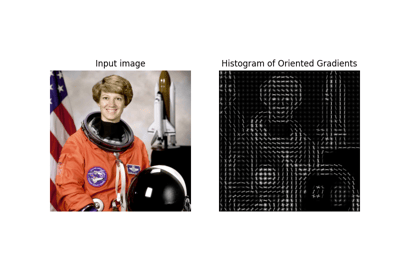

[Histogram of Oriented Gradients](https://scikit-image.org/docs/0.26.x/auto_examples/features_detection/plot_hog.html)

Histogram of Oriented Gradients

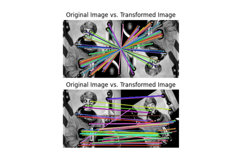

[ORB feature detector and binary descriptor](https://scikit-image.org/docs/0.26.x/auto_examples/features_detection/plot_orb.html)

ORB feature detector and binary descriptor

[figure not shown]

[SIFT feature detector and descriptor extractor](https://scikit-image.org/docs/0.26.x/auto_examples/features_detection/plot_sift.html)

SIFT feature detector and descriptor extractor

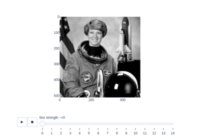

[Estimate strength of blur](https://scikit-image.org/docs/0.26.x/auto_examples/filters/plot_blur_effect.html)

Estimate strength of blur

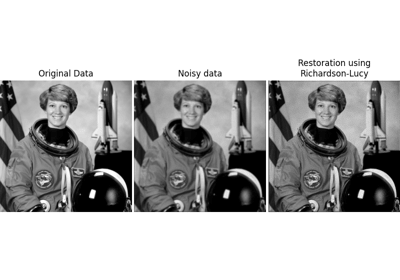

[Image Deconvolution](https://scikit-image.org/docs/0.26.x/auto_examples/filters/plot_deconvolution.html)

Image Deconvolution

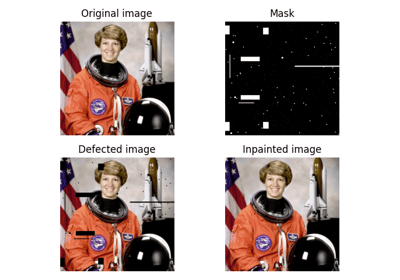

[Fill in defects with inpainting](https://scikit-image.org/docs/0.26.x/auto_examples/filters/plot_inpaint.html)

Fill in defects with inpainting

[figure not shown]

[Non-local means denoising for preserving textures](https://scikit-image.org/docs/0.26.x/auto_examples/filters/plot_nonlocal_means.html)

Non-local means denoising for preserving textures

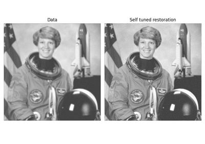

[Image Deconvolution](https://scikit-image.org/docs/0.26.x/auto_examples/filters/plot_restoration.html)

Image Deconvolution

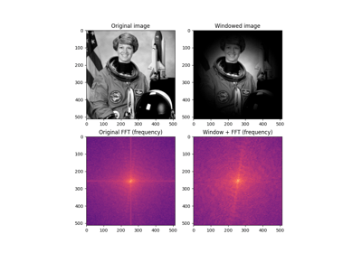

[Using window functions with images](https://scikit-image.org/docs/0.26.x/auto_examples/filters/plot_window.html)

Using window functions with images

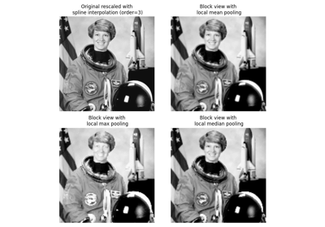

[Block views on images/arrays](https://scikit-image.org/docs/0.26.x/auto_examples/numpy_operations/plot_view_as_blocks.html)

Block views on images/arrays

[Flood Fill](https://scikit-image.org/docs/0.26.x/auto_examples/segmentation/plot_floodfill.html)

Flood Fill

[figure not shown]

[Comparison of segmentation and superpixel algorithms](https://scikit-image.org/docs/0.26.x/auto_examples/segmentation/plot_segmentations.html)

Comparison of segmentation and superpixel algorithms

[figure not shown]

[Piecewise Affine Transformation](https://scikit-image.org/docs/0.26.x/auto_examples/transform/plot_piecewise_affine.html)

Piecewise Affine Transformation

[figure not shown]

[Build image pyramids](https://scikit-image.org/docs/0.26.x/auto_examples/transform/plot_pyramid.html)

Build image pyramids

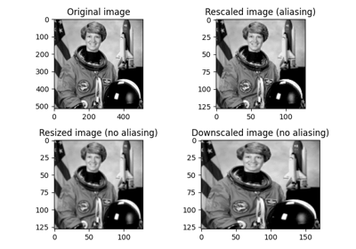

[Rescale, resize, and downscale](https://scikit-image.org/docs/0.26.x/auto_examples/transform/plot_rescale.html)

Rescale, resize, and downscale

**`skimage.data.binary_blobs(length=512, blob_size_fraction=0.1, n_dim=2, volume_fraction=0.5, rng=None, *, boundary_mode='nearest')` [[source]](https://github.com/scikit-image/scikit-image/blob/v0.26.0/skimage/data/_binary_blobs.py#L8-L106)**

Generate synthetic binary image with several rounded blob-like objects.

**Parameters:**

**`lengthint, optional`**

Linear size of output image.

**`blob_size_fractionfloat, optional`**

Typical linear size of blob, as a fraction of `length`, should be smaller than 1.

**`n_dimint, optional`**

Number of dimensions of output image.

**`volume_fractionfloat, default 0.5`**

Fraction of image pixels covered by the blobs (where the output is 1). Should be in [0, 1].

**`rng{numpy.random.Generator, int}, optional`**

Pseudo-random number generator. By default, a PCG64 generator is used (see [`numpy.random.default_rng()`](https://numpy.org/doc/stable/reference/random/generator.html#numpy.random.default_rng)). If `rng` is an int, it is used to seed the generator.

**`boundary_mode{‘nearest’, ‘wrap’}, optional`**

The blobs are created by smoothing and then thresholding an array consisting of ones at seed positions. This mode determines which values are filled in when the smoothing kernel overlaps the seed array’s boundary.

**`‘nearest’ (a a a a | a b c d | d d d d)`**

By default, when applying the Gaussian filter, the seed array is extended by replicating the last boundary value. This will increase the size of blobs whose seed or center lies exactly on the edge.

**`‘wrap’ (a b c d | a b c d | a b c d)`**

The seed array is extended by wrapping around to the opposite edge. The resulting blob array can be tiled and blobs will be contiguous and have smooth edges across tile boundaries.

**`boundary_modestr, default “nearest”`**

The `mode` parameter passed to the Gaussian filter. Use “wrap” for periodic boundary conditions.

**Returns:**

**`blobsndarray of bools`**

Output binary image

#### Examples

```
>>> from skimage import data
>>> data.binary_blobs(length=5, blob_size_fraction=0.2)
array([[ True, False,  True,  True,  True],
       [ True,  True,  True, False,  True],
       [False,  True, False,  True,  True],
       [ True, False, False,  True,  True],
       [ True, False, False, False,  True]])
>>> blobs = data.binary_blobs(length=256, blob_size_fraction=0.1)
>>> # Finer structures
>>> blobs = data.binary_blobs(length=256, blob_size_fraction=0.05)
>>> # Blobs cover a smaller volume fraction of the image
>>> blobs = data.binary_blobs(length=256, volume_fraction=0.3)
```

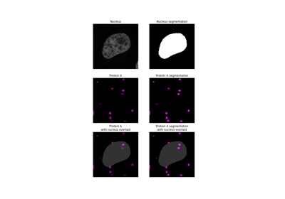

[Colocalization metrics](https://scikit-image.org/docs/0.26.x/auto_examples/applications/plot_colocalization_metrics.html)

Colocalization metrics

[General-purpose images](https://scikit-image.org/docs/0.26.x/auto_examples/data/plot_general.html)

General-purpose images

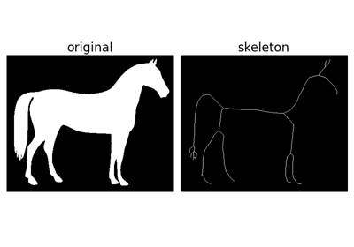

[Skeletonize](https://scikit-image.org/docs/0.26.x/auto_examples/edges/plot_skeleton.html)

Skeletonize

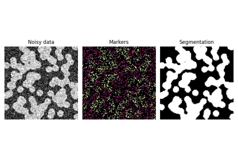

[Random walker segmentation](https://scikit-image.org/docs/0.26.x/auto_examples/segmentation/plot_random_walker_segmentation.html)

Random walker segmentation

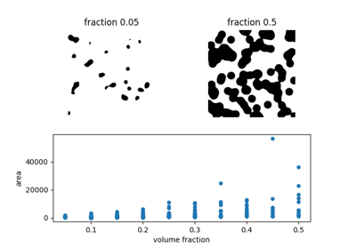

[Explore and visualize region properties with pandas](https://scikit-image.org/docs/0.26.x/auto_examples/segmentation/plot_regionprops_table.html)

Explore and visualize region properties with pandas

**`skimage.data.brain()` [[source]](https://github.com/scikit-image/scikit-image/blob/v0.26.0/skimage/data/_fetchers.py#L1227-L1246)**

Subset of data from the University of North Carolina Volume Rendering Test Data Set.

The full dataset is available at [1].

**Returns:**

**`image(10, 256, 256) uint16 ndarray`**

#### Notes

The 3D volume consists of 10 layers from the larger volume.

#### References

https://graphics.stanford.edu/data/voldata/

[Rank filters](https://scikit-image.org/docs/0.26.x/auto_examples/applications/plot_rank_filters.html)

Rank filters

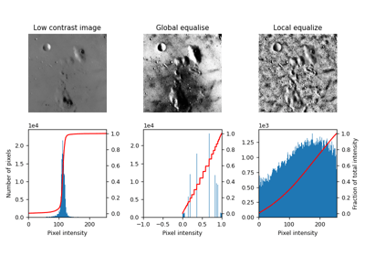

[Local Histogram Equalization](https://scikit-image.org/docs/0.26.x/auto_examples/color_exposure/plot_local_equalize.html)

Local Histogram Equalization

**`skimage.data.brick()` [[source]](https://github.com/scikit-image/scikit-image/blob/v0.26.0/skimage/data/_fetchers.py#L425-L488)**

Brick wall.

**Returns:**

**`brick(512, 512) uint8 image`**

A small section of a brick wall.

#### Notes

The original image was downloaded from [CC0Textures](https://cc0textures.com/view.php?tex=Bricks25) and licensed under the Creative Commons CC0 License.

A perspective transform was then applied to the image, prior to rotating it by 90 degrees, cropping and scaling it to obtain the final image.

[General-purpose images](https://scikit-image.org/docs/0.26.x/auto_examples/data/plot_general.html)

General-purpose images

[Gabor filter banks for texture classification](https://scikit-image.org/docs/0.26.x/auto_examples/features_detection/plot_gabor.html)

Gabor filter banks for texture classification

[Local Binary Pattern for texture classification](https://scikit-image.org/docs/0.26.x/auto_examples/features_detection/plot_local_binary_pattern.html)

Local Binary Pattern for texture classification

**`skimage.data.camera()` [[source]](https://github.com/scikit-image/scikit-image/blob/v0.26.0/skimage/data/_fetchers.py#L360-L382)**

Gray-level “camera” image.

Can be used for segmentation and denoising examples.

**Returns:**

**`camera(512, 512) uint8 ndarray`**

Camera image.

#### Notes

No copyright restrictions. CC0 by the photographer (Lav Varshney).